# Natural Language Processing with Tensorflow

# Introduction:

### In this project I will analyze text using Natural Language Processing. To accomplish this I will use Tensorflow. Why use Tensorflow, according to (Alsora, 1998) "The aim of this framework is to allow to easily design networks for any NLP task, using modular code and always maintaining the same input/output structure. This is extremely useful if your main use case is the deploy of a saved model in production, even if you want to access to this model using different programming languages."

# Goal:

### The goal of this project is to build a NLP API within Tensorflow that can text a string of text and predict if the customer either liked, or disliked the product that they reviewed. For this project I will using product reviews pulled from Amazon.

## Step One: Import required packages

```python
import matplotlib.pyplot as plt
```

```python
import tensorflow as tf
```

```python
%load_ext tensorboard
```

```python
import datetime
```

```python
from tensorflow import keras
```

```python
from tensorflow.keras import layers
```

```python
from tensorflow.keras.layers import Dense
from tensorflow.keras.models import Sequential
```

```python
from tensorflow.keras.preprocessing.text import Tokenizer
```

```python
from sklearn.metrics import mean_squared_error
```

```python
from sklearn.feature_extraction.text import CountVectorizer
```

```python
from sklearn.model_selection import train_test_split
```

```python
from keras.preprocessing.sequence import pad_sequences
```

```python
from pprint import pprint
```

```python
from collections import defaultdict
```

```python
import pandas as pd
```

```python
pd.set_option('display.max_rows', 1000)
```

```python
import numpy as np
```

```python
from nltk.tokenize import regexp_tokenize
```

```python
import gensim
```

```python
from gensim import corpora
```

```python
from gensim.corpora.dictionary import Dictionary
```

```python
import nltk
```

```python
from nltk.corpus import stopwords
```

```python
from sklearn.feature_extraction.text import TfidfVectorizer
```

```python
import string
```

```python
import re
```

# Step Two: Import and prepare the data (Foy, 2020)

```python
data = pd.read_csv('amazon_cells_labelled.csv', sep=",")
```

```python
data.rename(columns={'Liked/Disliked' : 'score', 'Review': 'text'}, inplace=True)
```

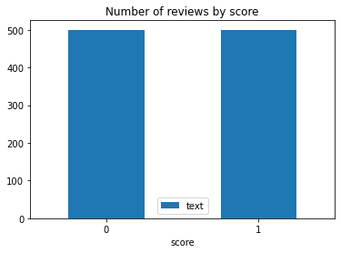

```python
ax = data.groupby('score').count().plot.bar(ylim=0)
ax.set_title('Number of reviews by score')
plt.xticks(rotation=0);
```

### The data contains two columns, first a column of cell phone reviews and then a column of 1's and 0's indicating if the customer liked the phone or not. From the graph above it is clear that the number of positive and negative reviews is equal.

### To prepare the data first all NA's will be removed, then all special characters will be removed, then all numbers will be removed, and finally all capital letters will be replaced with lowercase letters.

# Next remove NA's from the data

```python
df = data.dropna(subset=['text'])
```

# Next remove any special characters from the text column (Petit, 2020)

```python
spec_chars = ["!",'"',"#","%","&","'","(",")",
              "*","+",",","-",".","/",":",";","<",
              "=",">","?","@","[","\\","]","^","_",
              "`","{","|","}","~","–"]
```

```python
for char in spec_chars:
    df['text'] = df['text'].str.replace(char, ' ')
```

# Remove numbers from the text column

```python
df['text'] = df['text'].str.replace('\d+', '')
```

# Next replace all captial letters with lowercase

```python
df['text'] = df['text'].str.lower()
```

# Next tokenize the text column, for this part I followed the following guide: (Jedamski, 2020)

### To tokenize the words in the reviews I will define a function named tokenize, this function will split each sentence into it's individual words. Once we have the words seperated, we can filter out stopwords and then apply a vectorization to words replacing them with numerical values. We do this because Tensorflow cannot handle lists of string characters.

```python
def tokenize(text):
    tokens = re.split('\W+', text)
    return tokens

df['text_tokenized'] = df['text'].apply(lambda x: tokenize(x))
df.head()
```

|  | text | score | text_tokenized |
| --- | --- | --- | --- |
| 0 | so there is no way for me to plug it in here i... | 0 | [so, there, is, no, way, for, me, to, plug, it... |
| 1 | good case excellent value | 1 | [good, case, excellent, value, ] |
| 2 | great for the jawbone | 1 | [great, for, the, jawbone, ] |
| 3 | tied to charger for conversations lasting more... | 0 | [tied, to, charger, for, conversations, lastin... |
| 4 | the mic is great | 1 | [the, mic, is, great, ] |

# Load stopwords

```python
stopwords = nltk.corpus.stopwords.words('english')
```

# Next remove the stopwords

```python
def remove_stopwords(text_tokenized):
    text = [word for word in text_tokenized if word not in stopwords]
    return text

df['text_nostop'] = df['text_tokenized'].apply(lambda x: remove_stopwords(x))
df.head()
```

|  | text | score | text_tokenized | text_nostop |
| --- | --- | --- | --- | --- |
| 0 | so there is no way for me to plug it in here i... | 0 | [so, there, is, no, way, for, me, to, plug, it... | [way, plug, us, unless, go, converter, ] |
| 1 | good case excellent value | 1 | [good, case, excellent, value, ] | [good, case, excellent, value, ] |
| 2 | great for the jawbone | 1 | [great, for, the, jawbone, ] | [great, jawbone, ] |
| 3 | tied to charger for conversations lasting more... | 0 | [tied, to, charger, for, conversations, lastin... | [tied, charger, conversations, lasting, minute... |
| 4 | the mic is great | 1 | [the, mic, is, great, ] | [mic, great, ] |

```python
line_num_words = [len(t_line) for t_line in df['text_nostop']]
```

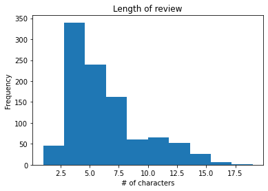

```python
plt.hist(line_num_words)
plt.title('Length of review')
plt.xlabel('# of characters')
plt.ylabel('Frequency');
```

```python
df['text_final'] = df['text_nostop'].apply(lambda x: ' '.join(x))
```

```python
tfidf_vect = TfidfVectorizer()
X_tfidf = tfidf_vect.fit_transform(df['text_final'])
print(X_tfidf.shape)
print(tfidf_vect.get_feature_names())
```

```
(1000, 1686)
['abhor', 'ability', 'able', 'abound', 'absolutel', 'absolutely', 'ac', 'accept', 'acceptable', 'access', 'accessable', 'accessing', 'accessory', 'accessoryone', 'accidentally', 'accompanied', 'according', 'activate', 'activated', 'activesync', 'actually', 'ad', 'adapter', 'adapters', 'add', 'additi…
```

### From looking at the output of tfidf_vect we can see that there are 1686 words in the final cleaned dataset.

### The output, X_tfidf is in sparse matrix form, tensorflow cannot handle this object type. X_tfidf must be converted to a Pandas dataframe first.

```python
X_features = pd.DataFrame(X_tfidf.toarray())
X_features.head()
```

|  | 0 | 1 | 2 | 3 | 4 | 5 | 6 | 7 | 8 | 9 | ... | 1676 | 1677 | 1678 | 1679 | 1680 | 1681 | 1682 | 1683 | 1684 | 1685 |
| --- | --- | --- | --- | --- | --- | --- | --- | --- | --- | --- | --- | --- | --- | --- | --- | --- | --- | --- | --- | --- | --- |
| 0 | 0.0 | 0.0 | 0.0 | 0.0 | 0.0 | 0.0 | 0.0 | 0.0 | 0.0 | 0.0 | ... | 0.0 | 0.0 | 0.0 | 0.0 | 0.0 | 0.0 | 0.0 | 0.0 | 0.0 | 0.0 |
| 1 | 0.0 | 0.0 | 0.0 | 0.0 | 0.0 | 0.0 | 0.0 | 0.0 | 0.0 | 0.0 | ... | 0.0 | 0.0 | 0.0 | 0.0 | 0.0 | 0.0 | 0.0 | 0.0 | 0.0 | 0.0 |
| 2 | 0.0 | 0.0 | 0.0 | 0.0 | 0.0 | 0.0 | 0.0 | 0.0 | 0.0 | 0.0 | ... | 0.0 | 0.0 | 0.0 | 0.0 | 0.0 | 0.0 | 0.0 | 0.0 | 0.0 | 0.0 |
| 3 | 0.0 | 0.0 | 0.0 | 0.0 | 0.0 | 0.0 | 0.0 | 0.0 | 0.0 | 0.0 | ... | 0.0 | 0.0 | 0.0 | 0.0 | 0.0 | 0.0 | 0.0 | 0.0 | 0.0 | 0.0 |
| 4 | 0.0 | 0.0 | 0.0 | 0.0 | 0.0 | 0.0 | 0.0 | 0.0 | 0.0 | 0.0 | ... | 0.0 | 0.0 | 0.0 | 0.0 | 0.0 | 0.0 | 0.0 | 0.0 | 0.0 | 0.0 |

5 rows × 1686 columns

# Next export the cleaned dataset to csv

```python
X_features.to_csv('data_clean.csv')
```

# Building the model in Tensorflow (Load a Pandas.DataFrame | TensorFlow Core, 2021)

```python
target = df.pop('score')
```

```python
X_train, X_test, y_train, y_test = train_test_split(X_features, target, test_size=0.20, random_state=100)
```

```python
print(df.shape); print(X_train.shape); print(X_test.shape)
```

```
(1000, 4)
(800, 1686)
(200, 1686)
```